# EXAMEN DE CLUSTERING SESSION 1

MASTER 2 DATA-SCIENCE (INP-HB Côte D’Ivoire) Présentateur: KONE GOMPOU LOUA ALASSANE Professeur: M.Monsan Vincent

Date du jour : 2021-07-07

# EXERCICE 3

#IMPORTATION DES LIBRAIRIE

```r
library(dplyr)
```

```r
library(FactoMineR)
library(ggplot2)
library(factoextra)
library(Hmisc)
library(corrplot)
library(rmdformats)
```

# 1.Importation du fichier <<fromage.txt>>

```r
#Chargement des données
fromage <- read.table(file="fromage.txt",header=T,row.names=1,sep="\t",dec=".")
```

```r
#Affichage des 6 premieres lignes
print(head(fromage))
```

```
##             calories sodium calcium lipides retinol folates proteines
## CarredelEst      314  353.5    72.6    26.3    51.6    30.3      21.0
## Babybel          314  238.0   209.8    25.1    63.7     6.4      22.6
## Beaufort         401  112.0   259.4    33.3    54.9     1.2      26.6
## Bleu             342  336.0   211.1    28.9    37.1    27.5      20.2
## Camembert        264  314.0   215.9    19.5   103.0    36.4      23.4
## Cantal           367  256.0   264.0    28.8    48.8     5.7      23.0
##             cholesterol magnesium
## CarredelEst          70        20
## Babybel              70        27
## Beaufort            120        41
## Bleu                 90        27
## Camembert            60        20
## Cantal               90        30
```

```r
#Statistiques descriptives
print(summary(fromage))
```

```
##     calories       sodium         calcium         lipides         retinol
##  Min.   : 70   Min.   : 22.0   Min.   : 72.6   Min.   : 3.40   Min.   : 37.10
##  1st Qu.:292   1st Qu.:140.0   1st Qu.:132.9   1st Qu.:23.40   1st Qu.: 51.60
##  Median :321   Median :223.0   Median :202.3   Median :26.30   Median : 62.30
##  Mean   :300   Mean   :210.1   Mean   :185.7   Mean   :24.16   Mean   : 67.56
##  3rd Qu.:355   3rd Qu.:276.0   3rd Qu.:220.5   3rd Qu.:29.10   3rd Qu.: 76.40
##  Max.   :406   Max.   :432.0   Max.   :334.6   Max.   :33.30   Max.   :150.50
##     folates        proteines      cholesterol       magnesium
##  Min.   : 1.20   Min.   : 4.10   Min.   : 10.00   Min.   :10.00
##  1st Qu.: 4.90   1st Qu.:17.80   1st Qu.: 70.00   1st Qu.:20.00
##  Median : 6.40   Median :21.00   Median : 80.00   Median :26.00
##  Mean   :13.01   Mean   :20.17   Mean   : 74.59   Mean   :26.97
##  3rd Qu.:21.10   3rd Qu.:23.40   3rd Qu.: 90.00   3rd Qu.:30.00
##  Max.   :36.40   Max.   :35.70   Max.   :120.00   Max.   :51.00
```

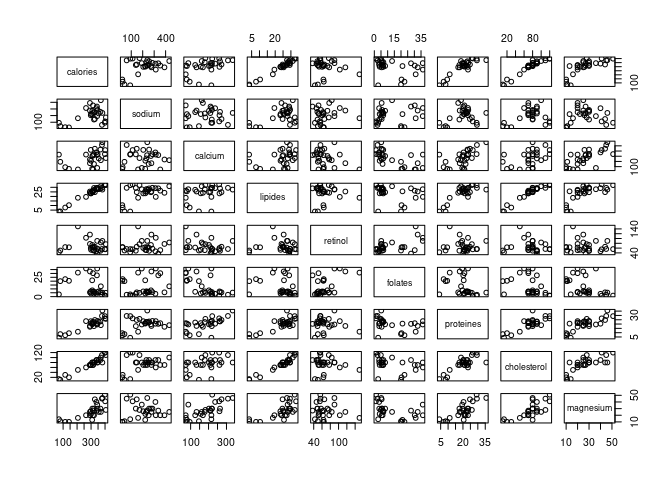

```r
#Graphique de croisement 2 à deux
pairs(fromage)
```

## Ce type de graphique n’est jamais anodin. Nous constatons par exemple que (1) «lipides» est fortement corrélé avec «calories» et «cholestérol».Ensuite (2) dans certaines configurations, des groupes semblent apparaître naturellement par exemple le croisement de «protéines» et «cholestérol», avec une corrélation inter-groupesassez marquée.`

# 2.Pensez-vous qu’il faut reduire les données avant la classification

## Pour éviter que variables à forte variance pèsent indûment sur les résultat, justement nous devons bien passer au centrage et à la réductionde nos données avant la classification.

```r
#Centrage et reduction des données
fromage_centre_reduit <-scale(fromage,center = T,scale = T)
```

```r
#Matrice des distance entre individus
distance.fromage <- dist(fromage_centre_reduit)
```

# 3.Classification hiérarchique par la méthode de Ward de nos données réduites

```r
#CAH - CRitère de Ward
#Méthode = <<Ward.D2>> correspondant au vrai critère de Ward utilisant les carrés de la distance
cah.ward <- hclust(distance.fromage, method = "ward.D2")
```